# Holt-Winter’s method in R

Week 12 R-lab:Dealing with trends and seasonality  
Zhaohu(Jonathan) Fan

07/29/2021

## Forecasting Method(s)

- 1. Define Goal
- 2. Get Data
- 3. Explore & Visualize Series
- 4. Pre-Process Data
- 5. Partition Series
- 6. $\color{red}{\text{Apply Forecasting Method(s): Holt-Winter’s method}}$
- 7. Evaluate & Compare Performance
- 8. Implement Forecasts/System

# Main Ideas

- Holt-Winter’s can capture a seasonal component
- Seasonality can be additive

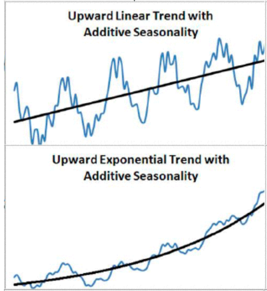

# Main Ideas (cont’d)

- Seasonality can be multiplicative

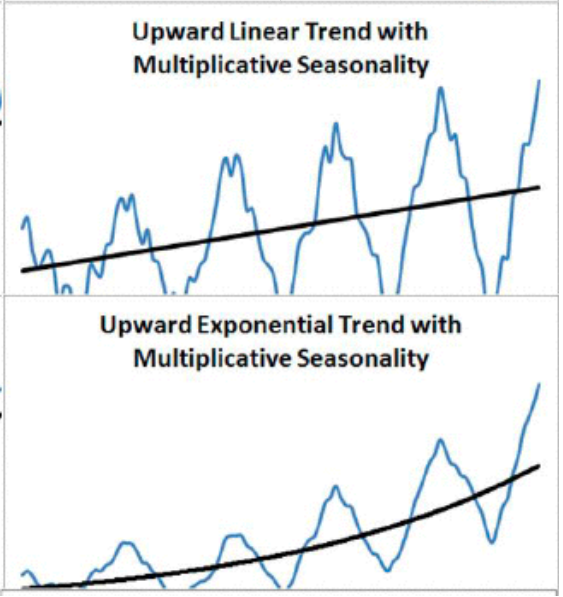

# The (Additive) Equation

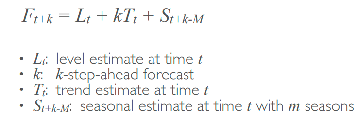

# The Updating Equations

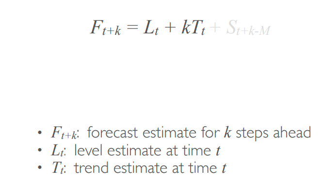

$\color{red}{\text{This is the same as before.}}$

# The Updating Equations (cont’d)

- Seasonality at time t is a weighted average of the seasonality in the previous period and the more recent information on the change in level.

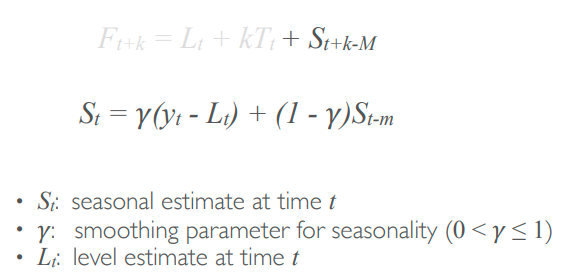

# Additive VS Multiplicative Seasonality

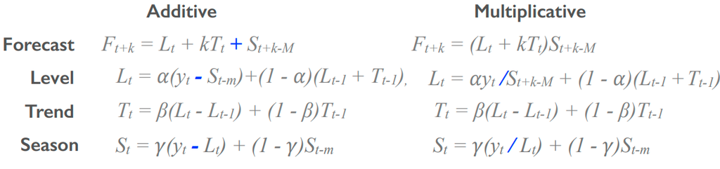

# Technical Notes

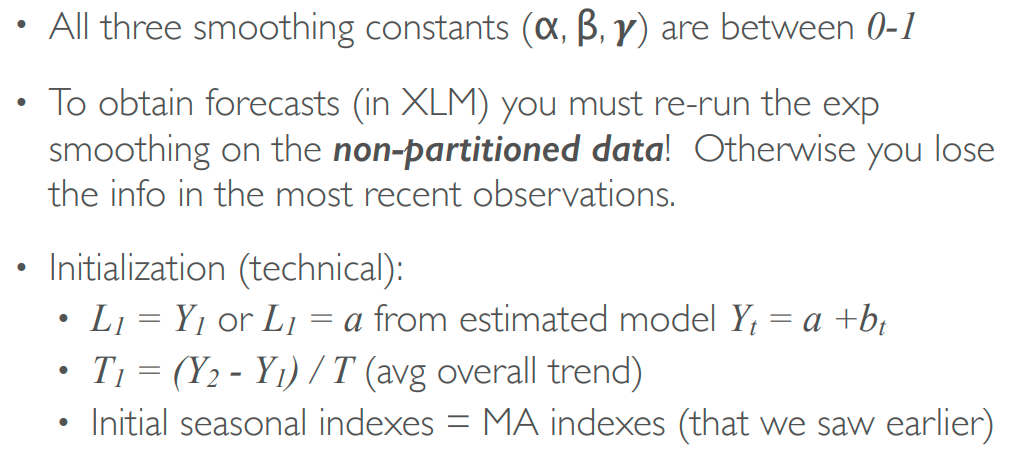

# Data Example (Let’s practice!)

- Our goal is to use monthly Australian sales of wine Jan 1980 - Dec-1994 to forecast the next year’s sales for fortified wine.
- Step 1: Load packages used

```r
library(tidyverse)
library(readxl)
library(fpp2)
```

- Step 2: Import and convert fortified wine to time series object.

```r
setwd("C:/Users/fanzh/OneDrive - University of Cincinnati/UC_couse/000_Teaching_4090_SP21/BANA4090_R_lab/Week12")
wine <- read_excel("AustralianWines.xls",
                   col_types = c("date", "numeric", "numeric", "numeric", "numeric",
                                 "numeric", "numeric"))
head(wine)
```

```
## # A tibble: 6 x 7
##   Month               Fortified   Red  Rose sparkling `Sweet white` `Dry white`
##   <dttm>                  <dbl> <dbl> <dbl>     <dbl>         <dbl>       <dbl>
## 1 1980-01-01 00:00:00      2585   464   112      1686            85        1954
## 2 1980-02-01 00:00:00      3368   675   118      1591            89        2302
## 3 1980-03-01 00:00:00      3210   703   129      2304           109        3054
## 4 1980-04-01 00:00:00      3111   887    99      1712            95        2414
## 5 1980-05-01 00:00:00      3756  1139   116      1471            91        2226
## 6 1980-06-01 00:00:00      4216  1077   168      1377            95        2725
```

```r
fortified.ts <- ts(wine$Fortified, start =c(1980, 1), end = c(1994, 12), freq = 12)
```

# Data Example (cont’d)

- Step 3: view the plot to verify (visualize the data to understand its attributes).

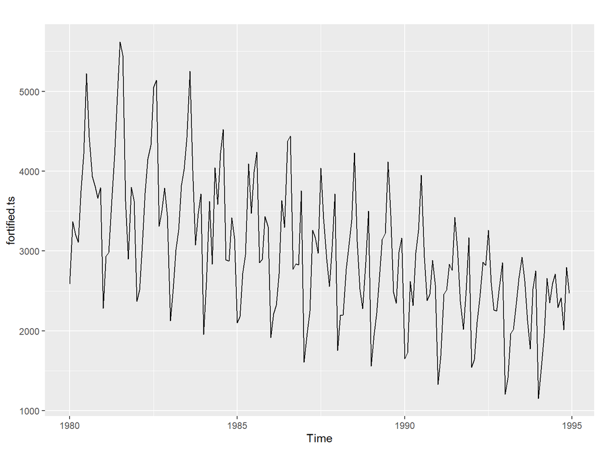

```r
autoplot(fortified.ts)
```

# Data Example (cont’d)

- Step 4: Next, partition the data using all data through Dec-1993 as the training period (Create time series for training and validation partitions).

```r
library(forecast)
train <- window(fortified.ts, end = c(1993, 12))
test <- window(fortified.ts, start = c(1994, 1))
train
```

```
##       Jan  Feb  Mar  Apr  May  Jun  Jul  Aug  Sep  Oct  Nov  Dec
## 1980 2585 3368 3210 3111 3756 4216 5225 4426 3932 3816 3661 3795
## 1981 2285 2934 2985 3646 4198 4935 5618 5454 3624 2898 3802 3629
## 1982 2369 2511 3079 3728 4151 4326 5054 5138 3310 3508 3790 3446
## 1983 2127 2523 3017 3265 3822 4027 4420 5255 4009 3074 3465 3718
## 1984 1954 2604 3626 2836 4042 3584 4225 4523 2892 2876 3420 3159
## 1985 2101 2181 2724 2954 4092 3470 3990 4239 2855 2897 3433 3307
## 1986 1914 2214 2320 2714 3633 3295 4377 4442 2774 2840 2828 3758
## 1987 1610 1968 2248 3262 3164 2972 4041 3402 2898 2555 3056 3717
## 1988 1755 2193 2198 2777 3076 3389 4231 3118 2524 2280 2862 3502
## 1989 1558 1940 2226 2676 3145 3224 4117 3446 2482 2349 2986 3163
## 1990 1651 1725 2622 2316 2976 3263 3951 2917 2380 2458 2883 2579
## 1991 1330 1686 2457 2514 2834 2757 3425 3006 2369 2017 2507 3168
## 1992 1545 1643 2112 2415 2862 2822 3260 2606 2264 2250 2545 2856
## 1993 1208 1412 1964 2018 2329 2660 2923 2626 2132 1772 2526 2755
```

```r
test
```

```
##       Jan  Feb  Mar  Apr  May  Jun  Jul  Aug  Sep  Oct  Nov  Dec
## 1994 1154 1568 1965 2659 2354 2592 2714 2294 2416 2016 2799 2467
```

# Data Example (cont’d)

- Apply Holt-Winter’s exponential smoothing to sales. Apply two models:
  - One with additive seasonality
  - One with multiplicative seasonality
- Compare the performance of these two models
- Step 5: Apply Holt-Winter’s exponential smoothing - 2 models:
  - Model 1: additive seasonality

```r
hw.add <- HoltWinters(train, seasonal = "additive")
hw.add
```

```
## Holt-Winters exponential smoothing with trend and additive seasonal component.
##
## Call:
## HoltWinters(x = train, seasonal = "additive")
##
## Smoothing parameters:
##  alpha: 0.05510535
##  beta : 0.1588215
##  gamma: 0.5329381
##
## Coefficients:
##            [,1]
## a    2288.82005
## b     -14.80163
## s1  -1227.76935
## s2  -1020.24058
## s3   -449.66968
## s4   -316.36241
## s5     71.98521
## s6    259.33499
## s7    691.90564
## s8    249.61420
## s9   -233.43031
## s10  -457.87296
## s11   132.08658
## s12   418.49166
```

- Model 2: multiplicative seasonality

```r
hw.mult <- HoltWinters(train, seasonal = "multiplicative")
hw.mult
```

```
## Holt-Winters exponential smoothing with trend and multiplicative seasonal component.
##
## Call:
## HoltWinters(x = train, seasonal = "multiplicative")
##
## Smoothing parameters:
##  alpha: 0.04532094
##  beta : 0.2355805
##  gamma: 0.4606459
##
## Coefficients:
##             [,1]
## a   2221.1061208
## b    -15.7122359
## s1     0.5378698
## s2     0.6207052
## s3     0.8452159
## s4     0.9008388
## s5     1.0580553
## s6     1.1294257
## s7     1.3124112
## s8     1.1268029
## s9     0.9241528
## s10    0.8337720
## s11    1.0756691
## s12    1.1966389
```

# Data Example (cont’d)

- Step 6: Forecast and compare prediction accuracy

```r
for.add <- forecast(hw.add, h = 12)
for.mult <- forecast(hw.mult, h = 12)

accuracy(for.add, test)
```

```
##                     ME     RMSE      MAE        MPE      MAPE     MASE
## Training set -23.95621 314.0081 235.8465 -0.9831727  7.856148 0.847587
## Test set     214.05112 344.1063 272.6891  9.7704548 12.111263 0.979992
##                     ACF1 Theil's U
## Training set  0.08427367        NA
## Test set     -0.07014781 0.8273712
```

```r
accuracy(for.mult, test)
```

```
##                     ME     RMSE      MAE       MPE      MAPE      MASE
## Training set -23.76725 305.2967 228.6527 -1.405757  7.645291 0.8217339
## Test set     215.98096 330.4588 241.9785  8.974235 10.275026 0.8696240
##                     ACF1 Theil's U
## Training set  0.04603664        NA
## Test set     -0.15166444 0.7651015
```

# Data Example (cont’d)

- Step 7 (optional): An alternative to finding the preferred model structure (ets is a universal exponential smoothing model function).

```r
# ets is a universal exponential smoothing model function
ets(train)
```

```
## ETS(M,A,M)
##
## Call:
##  ets(y = train)
##
##   Smoothing parameters:
##     alpha = 0.0243
##     beta  = 0.0011
##     gamma = 1e-04
##
##   Initial states:
##     l = 4049.4027
##     b = -12.1017
##     s = 1.1369 1.0373 0.8857 0.9522 1.2762 1.3697
##            1.1443 1.1121 0.9335 0.8626 0.7041 0.5855
##
##   sigma:  0.091
##
##      AIC     AICc      BIC
## 2753.520 2757.600 2806.628
```

```r
hw.mult2 <- ets(train, model = "MAM")
for.mult2 <- forecast(hw.mult2, h = 12)
accuracy(for.mult, test)
```

```
##                     ME     RMSE      MAE       MPE      MAPE      MASE
## Training set -23.76725 305.2967 228.6527 -1.405757  7.645291 0.8217339
## Test set     215.98096 330.4588 241.9785  8.974235 10.275026 0.8696240
##                     ACF1 Theil's U
## Training set  0.04603664        NA
## Test set     -0.15166444 0.7651015
```

```r
accuracy(for.mult2, test)
```

```
##                    ME     RMSE      MAE         MPE      MAPE      MASE
## Training set 15.49844 285.2321 222.3198 -0.04620971  7.098462 0.7989745
## Test set     98.19161 318.9037 242.6523  3.22878698 10.237376 0.8720456
##                     ACF1 Theil's U
## Training set  0.06838359        NA
## Test set     -0.04043727 0.6850152
```

- So we know that a Holt-Winter’s model with additive trend, multiplicative seasonality (and multiplicative error) is the preferred Holt-Winter’s model structure. $\color{red}{\text{Now can we tune the gamma smoothing parameter to find the optimal Holt-Winter’s model? }}$

# Data Example (cont’d)

- Step 8 :Identify optimal gamma Vector of values from 0.0001 to 0.95 with step 0.01 ( The gamma parameter captures seasonality. We can identify the gamma that reduces forecast error).

```r
gamma <- seq(0.0001, 0.95, 0.01)
```

```r
RMSE <- NA
```

- Iterate through all values of vector gamma.

```r
for(i in seq_along(gamma)) {
  hw.opt <- ets(train, "MAM", gamma = gamma[i])
  future <- forecast(hw.opt, h = 12)
  RMSE[i] = accuracy(future, test)[2,2]
}
```

```r
error <- data_frame(gamma, RMSE)
minimum <- filter(error, RMSE == min(RMSE))
minimum
```

```
## # A tibble: 1 x 2
##   gamma  RMSE
##   <dbl> <dbl>
## 1 0.560  284.
```

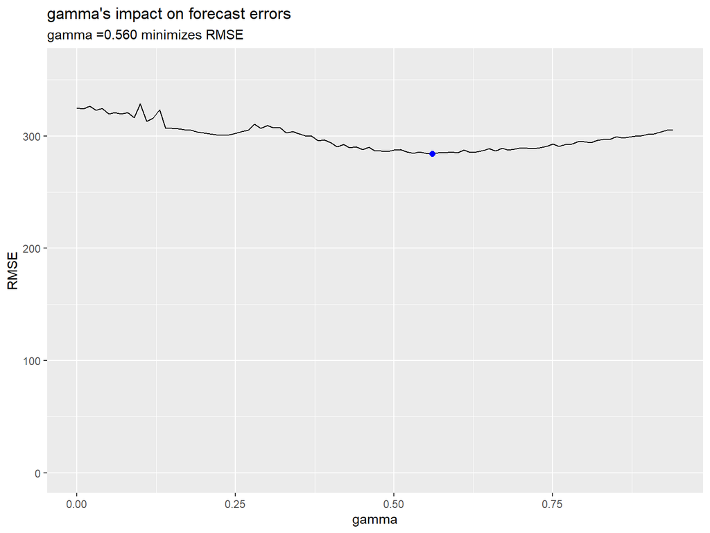

```r
ggplot(error, aes(gamma, RMSE)) +
  geom_line() +
  geom_point(data = minimum, color = "blue", size = 2) +
  scale_y_continuous(limits = c(0, 360)) +
  ggtitle("gamma's impact on forecast errors",
          subtitle = "gamma =0.560 minimizes RMSE")
```

# Data Example (cont’d)

- Step 9 : Apply Holt-Winter’s exponential smoothing with optimal gamma:

```r
hw.opt <- ets(train, "MAM", gamma = 0.560)
```

- Compare on forecasted values:

```r
for.mult3 <- forecast(hw.opt, h = 12)
accuracy(for.mult2, test)
```

```
##                    ME     RMSE      MAE         MPE      MAPE      MASE
## Training set 15.49844 285.2321 222.3198 -0.04620971  7.098462 0.7989745
## Test set     98.19161 318.9037 242.6523  3.22878698 10.237376 0.8720456
##                     ACF1 Theil's U
## Training set  0.06838359        NA
## Test set     -0.04043727 0.6850152
```

```r
accuracy(for.mult3, test)
```

```
##                     ME     RMSE      MAE       MPE     MAPE      MASE
## Training set -11.07866 289.6720 229.3854 -1.037906 7.503154 0.8243671
## Test set     135.30848 284.3022 214.4008  5.473588 9.168268 0.7705151
##                     ACF1 Theil's U
## Training set  0.09441158        NA
## Test set     -0.14514834 0.6520969
```

# Data Example (cont’d)

- Step 10 : Plot the final model against the actual data

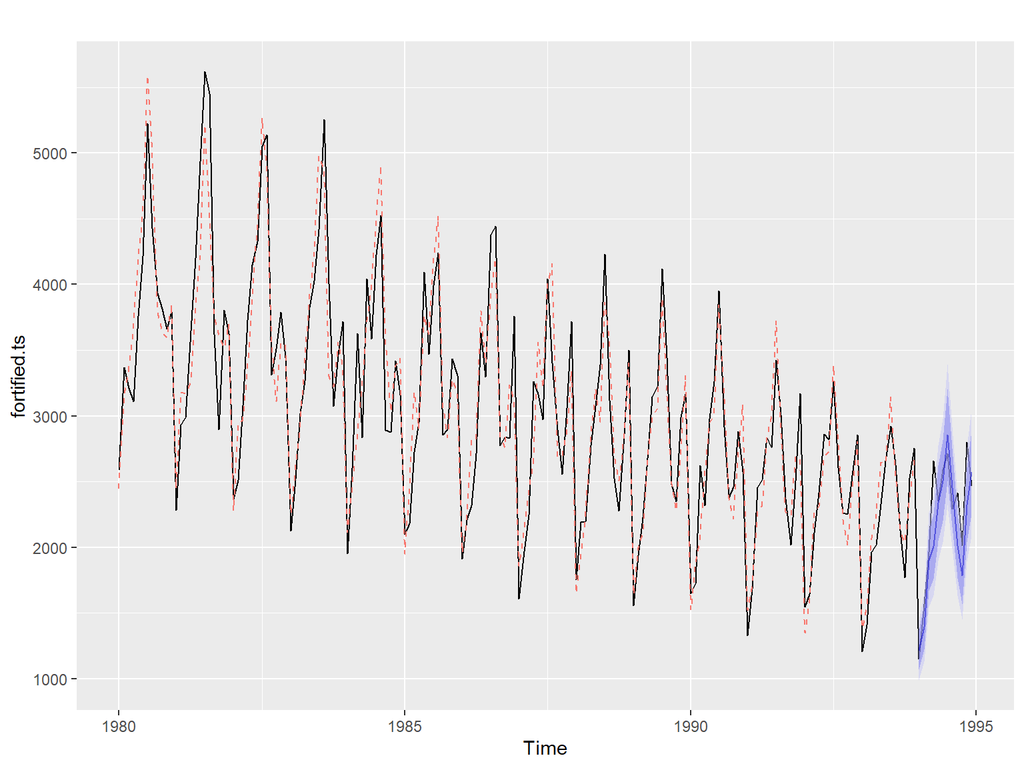

```r
autoplot(fortified.ts) +
  autolayer(fitted.values(for.mult3), linetype = "dashed", show.legend = FALSE) +
  autolayer(for.mult3, alpha = .50)
```